# PCA

Ekaterina_Kravchuk

06 12 2021

# 1. Data description

There are two files: (1) train.csv contains 81 features extracted from 21263 superconductors along with the critical temperature in the 82nd column, (2) unique_m.csv contains the chemical formula broken up for all the 21263 superconductors from the train.csv file. The last two columns have the critical temperature and chemical formula. The original data comes from https://supercon.nims.go.jp/en/ which is public. The goal here is to predict the critical temperature based on the features extracted.

## 1.1. Data preprocessing

The data is saved in csv format and requires preprocessing

```r
unique_m <- read.csv("~/data/unique_m.csv")
train <-read.csv("~/data/train.csv")
unique_m$material <- NULL
data <- cbind(unique_m, train)
write.csv(data, file = "~/data/pca_data.csv")
```

I saved the data to ~/data/pca_data.csv  
## 1.2. Data structure We work with 21263 observations of 169 variables

```r
str(data)
```

```
## 'data.frame':    21263 obs. of  169 variables:
##  $ H                              : num  0 0 0 0 0 0 0 0 0 0 ...
##  $ He                             : int  0 0 0 0 0 0 0 0 0 0 ...
##  $ Li                             : num  0 0 0 0 0 0 0 0 0 0 ...
##  $ Be                             : num  0 0 0 0 0 0 0 0 0 0 ...
##  $ B                              : num  0 0 0 0 0 0 0 0 0 0 ...
##  $ C                              : num  0 0 0 0 0 0 0 0 0 0 ...
##  $ N                              : num  0 0 0 0 0 0 0 0 0 0 ...
##  $ O                              : num  4 4 4 4 4 4 4 4 4 4 ...
##  $ F                              : num  0 0 0 0 0 0 0 0 0 0 ...
##  $ Ne                             : int  0 0 0 0 0 0 0 0 0 0 ...
##  $ Na                             : num  0 0 0 0 0 0 0 0 0 0 ...
##  $ Mg                             : num  0 0 0 0 0 0 0 0 0 0 ...
##  $ Al                             : num  0 0 0 0 0 0 0 0 0 0 ...
##  $ Si                             : num  0 0 0 0 0 0 0 0 0 0 ...
```

[output cut: 86 more lines]

## 1.3. Dividind the data into training and test samples

```r
smp_size <- floor(0.8 * nrow(data))
set.seed(8)
train_ind <- sample(seq_len(nrow(data)), size = smp_size)

train_data <- data[train_ind, ]
test_data <- data[-train_ind, ]
```

## 1.4. Standartization

Standartization of the train data

```r
st_train_data <- as.data.frame(scale(train_data, center=TRUE, scale = TRUE))
st_train_data$critical_temp <- train_data$critical_temp
```

Finding mean and sd column-wise of training data

```r
trainMean <- apply(train_data,2,mean)
trainSd <- apply(train_data,2,sd)
```

Standartization of test data

```r
st_test_data <- sweep(sweep(test_data, 2L, trainMean), 2, trainSd, "/")
st_test_data$critical_temp <- test_data$critical_temp
```

```r
st_train_data = rapply( st_train_data, f=function(x) ifelse(is.nan(x),0,x), how="replace" )
st_test_data = rapply( st_test_data, f=function(x) ifelse(is.nan(x),0,x), how="replace" )
```

# 2. Linear model: critical temperature prediction

# 2.1. Creating the model

```r
model1 <- lm(critical_temp ~ ., data = st_train_data, na.action = "na.exclude")
```

```r
summary(model1)
```

```
##
## Call:
## lm(formula = critical_temp ~ ., data = st_train_data, na.action = "na.exclude")
##
## Residuals:
##      Min       1Q   Median       3Q      Max
## -107.830   -8.330    0.651   10.261  169.790
##
## Coefficients: (9 not defined because of singularities)
##                                   Estimate Std. Error t value Pr(>|t|)
## (Intercept)                      3.461e+01  1.281e-01 270.103  < 2e-16 ***
## H                                6.693e-02  1.839e-01   0.364 0.715944
## He                                      NA         NA      NA       NA
## Li                               5.801e-01  1.721e-01   3.371 0.000752 ***
## Be                              -2.602e-01  1.538e-01  -1.692 0.090627 .
## B                               -3.066e-01  1.557e-01  -1.969 0.048945 *
## C                               -3.738e-04  3.137e-01  -0.001 0.999049
## N                               -3.404e-02  1.559e-01  -0.218 0.827218
## O                               -1.182e+00  4.424e-01  -2.672 0.007543 **
## F                                1.044e+00  1.828e-01   5.710 1.15e-08 ***
## Ne                                      NA         NA      NA       NA
## Na                               4.735e-01  1.700e-01   2.785 0.005363 **
## Mg                               2.112e-01  1.669e-01   1.265 0.205846
## Al                              -2.295e-01  1.436e-01  -1.599 0.109929
## Si                              -3.113e+00  1.948e-01 -15.980  < 2e-16 ***
## P                               -7.214e-01  1.576e-01  -4.577 4.74e-06 ***
## S                               -1.367e+00  1.976e-01  -6.922 4.62e-12 ***
## Cl                              -3.827e-01  2.052e-01  -1.865 0.062189 .
## Ar                                      NA         NA      NA       NA
## K                                1.023e+00  1.977e-01   5.174 2.32e-07 ***
## Ca                               1.044e+00  2.916e-01   3.579 0.000346 ***
## Sc                              -5.060e-02  1.370e-01  -0.369 0.711768
## Ti                              -1.882e-01  1.419e-01  -1.326 0.184880
## V                                5.882e-02  1.600e-01   0.368 0.713160
## Cr                              -8.046e-02  1.321e-01  -0.609 0.542594
## Mn                               9.691e-02  1.412e-01   0.686 0.492581
## Fe                               1.022e+00  2.720e-01   3.759 0.000171 ***
## Co                              -2.155e-01  1.408e-01  -1.530 0.126084
## Ni                              -2.140e-01  1.725e-01  -1.241 0.214589
## Cu                              -1.034e+00  2.096e-01  -4.931 8.26e-07 ***
```

[output cut: 129 more lines]

```
## wtd_mean_Valence                -1.184e+01  9.858e+00  -1.201 0.229677
## gmean_Valence                   -4.544e+00  6.700e+00  -0.678 0.497608
## wtd_gmean_Valence                8.667e+00  9.119e+00   0.950 0.341913
## entropy_Valence                  2.853e+01  5.673e+00   5.029 4.99e-07 ***
## wtd_entropy_Valence             -2.533e+01  2.369e+00 -10.690  < 2e-16 ***
## range_Valence                    6.757e+00  1.001e+00   6.750 1.53e-11 ***
## wtd_range_Valence               -2.162e+00  6.938e-01  -3.116 0.001837 **
## std_Valence                     -7.334e-01  1.343e+00  -0.546 0.585142
## wtd_std_Valence                 -6.604e+00  1.016e+00  -6.501 8.22e-11 ***
## ---
## Signif. codes:  0 '***' 0.001 '**' 0.01 '*' 0.05 '.' 0.1 ' ' 1
##
## Residual standard error: 16.71 on 16851 degrees of freedom
## Multiple R-squared:  0.765,  Adjusted R-squared:  0.7628
## F-statistic: 347.2 on 158 and 16851 DF,  p-value: < 2.2e-16
```

Adjusted R-squared on train data is 0.7628

## 2.2. Using the model to predict critical temperature using test dataset

Let’s make prediction using test data

```r
prediction <- predict(model1, st_test_data)
```

Is the prediction good?

```r
cor(prediction, st_test_data$critical_temp)
```

```
## [1] 0.5342501
```

```r
SS.total      <- sum((st_test_data$critical_temp - mean(st_test_data$critical_temp))^2)
SS.residual   <- sum((st_test_data$critical_temp - prediction)^2)
SS.regression <- sum((prediction - mean(st_test_data$critical_temp))^2)
SS.total <- (SS.regression+SS.residual)
test.rsq <- 1 - SS.residual/SS.total
test.adj_rsq <- 1 - (1 - test.rsq)*(nrow(st_test_data)-1)/(nrow(st_test_data)-ncol(st_test_data))
test.adj_rsq
```

```
## [1] 0.5578793
```

adjusted R-squared for test data is 0.5578793 The prediction does not meet our expectations. What should be done? Let’s use PCA

# 3. PCA

## 3.1. Performing PCA

```r
st_test_x <- st_test_data
st_test_x$critical_temp <- NULL
pca <- rda(st_test_x, scale = TRUE)
```

```r
head(summary(pca))
```

```
##
## Call:
## rda(X = st_test_x, scale = TRUE)
##
## Partitioning of correlations:
##               Inertia Proportion
## Total             159          1
## Unconstrained     159          1
##
## Eigenvalues, and their contribution to the correlations
##
## Importance of components:
##                           PC1     PC2     PC3     PC4     PC5     PC6     PC7
## Eigenvalue            33.0277 9.54726 8.54778 7.00866 5.36057 3.63705 3.50351
## Proportion Explained   0.2077 0.06005 0.05376 0.04408 0.03371 0.02287 0.02203
## Cumulative Proportion  0.2077 0.26777 0.32153 0.36561 0.39932 0.42219 0.44423
##                           PC8     PC9    PC10    PC11    PC12    PC13    PC14
## Eigenvalue            2.96540 2.62082 2.48214 2.17438 2.11390 2.04201 1.96479
## Proportion Explained  0.01865 0.01648 0.01561 0.01368 0.01329 0.01284 0.01236
## Cumulative Proportion 0.46288 0.47936 0.49497 0.50865 0.52194 0.53479 0.54714
##                          PC15    PC16    PC17   PC18     PC19     PC20     PC21
## Eigenvalue            1.92493 1.80074 1.72250 1.6210 1.583975 1.560692 1.477825
## Proportion Explained  0.01211 0.01133 0.01083 0.0102 0.009962 0.009816 0.009294
## Cumulative Proportion 0.55925 0.57058 0.58141 0.5916 0.601566 0.611382 0.620677
##                           PC22     PC23     PC24     PC25     PC26     PC27
## Eigenvalue            1.461300 1.393681 1.351130 1.320583 1.313109 1.281361
## Proportion Explained  0.009191 0.008765 0.008498 0.008306 0.008259 0.008059
## Cumulative Proportion 0.629867 0.638633 0.647130 0.655436 0.663694 0.671753
##                           PC28     PC29    PC30     PC31     PC32     PC33
## Eigenvalue            1.245255 1.218106 1.20209 1.177514 1.148357 1.124559
## Proportion Explained  0.007832 0.007661 0.00756 0.007406 0.007222 0.007073
## Cumulative Proportion 0.679585 0.687246 0.69481 0.702212 0.709434 0.716507
##                           PC34    PC35     PC36     PC37     PC38     PC39
## Eigenvalue            1.121090 1.10817 1.102677 1.075467 1.061648 1.040983
## Proportion Explained  0.007051 0.00697 0.006935 0.006764 0.006677 0.006547
## Cumulative Proportion 0.723558 0.73053 0.737463 0.744227 0.750904 0.757451
##                           PC40     PC41    PC42     PC43    PC44    PC45
## Eigenvalue            1.038125 1.036149 1.02865 1.017475 1.01285 1.00652
## Proportion Explained  0.006529 0.006517 0.00647 0.006399 0.00637 0.00633
## Cumulative Proportion 0.763980 0.770497 0.77697 0.783365 0.78974 0.79607
```

[output cut: 98 more lines]

```
## B    -2.394e-01 4.157e-01 -4.245e-01 6.090e-01  3.518e-01 -4.904e-01
## C    -1.580e-01 8.974e-01 -1.584e-01 1.090e-01  7.270e-01  7.863e-01
## ....
##
##
## Site scores (weighted sums of species scores)
##
##         PC1    PC2    PC3     PC4      PC5      PC6
## 3    0.2597 0.2197 0.4103 -0.2903 -0.04457 -0.05945
## 5    0.2860 0.2025 0.3922 -0.2621 -0.04731 -0.06025
## 6    0.3044 0.1944 0.3815 -0.2399 -0.05112 -0.06527
## 14   0.3395 0.0281 0.2353 -0.1910  0.08521  0.17372
## 25   0.2778 0.2375 0.3541 -0.2042 -0.10654 -0.07149
## 26   0.2823 0.2350 0.3494 -0.1964 -0.10944 -0.07140
## ....
```

```r
eigenvals(pca)
```

```
##      PC1      PC2      PC3      PC4      PC5      PC6      PC7      PC8
## 33.02766  9.54726  8.54778  7.00866  5.36057  3.63705  3.50351  2.96540
##      PC9     PC10     PC11     PC12     PC13     PC14     PC15     PC16
##  2.62082  2.48214  2.17438  2.11390  2.04201  1.96479  1.92493  1.80074
##     PC17     PC18     PC19     PC20     PC21     PC22     PC23     PC24
##  1.72250  1.62101  1.58398  1.56069  1.47783  1.46130  1.39368  1.35113
##     PC25     PC26     PC27     PC28     PC29     PC30     PC31     PC32
##  1.32058  1.31311  1.28136  1.24525  1.21811  1.20209  1.17751  1.14836
##     PC33     PC34     PC35     PC36     PC37     PC38     PC39     PC40
##  1.12456  1.12109  1.10817  1.10268  1.07547  1.06165  1.04098  1.03812
##     PC41     PC42     PC43     PC44     PC45     PC46     PC47     PC48
##  1.03615  1.02865  1.01747  1.01285  1.00652  0.99722  0.99021  0.98505
##     PC49     PC50     PC51     PC52     PC53     PC54     PC55     PC56
##  0.98073  0.96695  0.95127  0.94877  0.93528  0.92468  0.91652  0.89200
##     PC57     PC58     PC59     PC60     PC61     PC62     PC63     PC64
##  0.87970  0.87393  0.85956  0.84139  0.82572  0.78320  0.75091  0.74032
##     PC65     PC66     PC67     PC68     PC69     PC70     PC71     PC72
##  0.70789  0.69315  0.66874  0.66103  0.64726  0.61390  0.59285  0.57939
##     PC73     PC74     PC75     PC76     PC77     PC78     PC79     PC80
##  0.56607  0.54098  0.50853  0.50008  0.48367  0.44465  0.43826  0.43406
##     PC81     PC82     PC83     PC84     PC85     PC86     PC87     PC88
##  0.41145  0.38165  0.37267  0.36176  0.35226  0.33162  0.30734  0.29731
##     PC89     PC90     PC91     PC92     PC93     PC94     PC95     PC96
##  0.25669  0.23562  0.23177  0.21116  0.20186  0.18402  0.17465  0.16833
##     PC97     PC98     PC99    PC100    PC101    PC102    PC103    PC104
##  0.15006  0.14894  0.11925  0.10865  0.10403  0.09528  0.08814  0.08328
##    PC105    PC106    PC107    PC108    PC109    PC110    PC111    PC112
##  0.08311  0.07107  0.06492  0.05742  0.05528  0.05361  0.04989  0.04578
##    PC113    PC114    PC115    PC116    PC117    PC118    PC119    PC120
##  0.03608  0.03552  0.03408  0.02881  0.02780  0.02396  0.02309  0.01861
##    PC121    PC122    PC123    PC124    PC125    PC126    PC127    PC128
##  0.01768  0.01629  0.01522  0.01411  0.01295  0.01265  0.01218  0.01142
##    PC129    PC130    PC131    PC132    PC133    PC134    PC135    PC136
##  0.01033  0.01012  0.00834  0.00763  0.00714  0.00666  0.00590  0.00547
##    PC137    PC138    PC139    PC140    PC141    PC142    PC143    PC144
##  0.00524  0.00472  0.00416  0.00379  0.00318  0.00291  0.00252  0.00235
##    PC145    PC146    PC147    PC148    PC149    PC150    PC151    PC152
##  0.00204  0.00182  0.00150  0.00127  0.00118  0.00109  0.00099  0.00053
##    PC153    PC154    PC155    PC156    PC157    PC158    PC159
##  0.00044  0.00037  0.00027  0.00015  0.00011  0.00007  0.00004
```

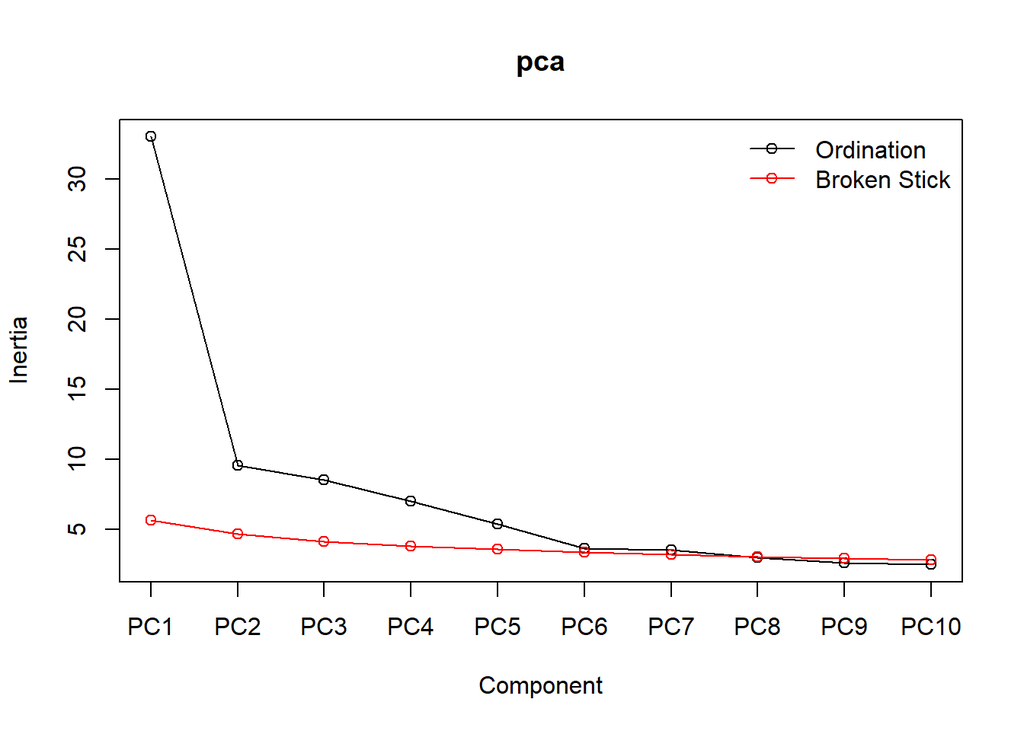

```r
screeplot(pca, type = "lines", bstick = TRUE)
```

## 3.2 Choosing PCs

I decided to choose 6 PCs

```r
my_matrix <- as.data.frame(summary(pca)$species[,1:6])
new_train <- as.data.frame(as.matrix(st_train_data[,-82]) %*% as.matrix(my_matrix))
train_crit_t <- train_data$critical_temp
new_train <- cbind(new_train, train_crit_t)
st_test_x <- st_test_data
st_test_x$critical_temp <- NULL
new_test <- as.data.frame(as.matrix(st_test_data[,-82]) %*% as.matrix(my_matrix))
test_crit_t <- test_data$critical_temp
new_test <- cbind(new_test, test_crit_t)
```

# 4. Linear model: critical temperature prediction after PCA

## 4.1. Creating the model

```r
model2 <- lm(train_crit_t~., data=new_train)
summary(model2)
```

```
##
## Call:
## lm(formula = train_crit_t ~ ., data = new_train)
##
## Residuals:
##     Min      1Q  Median      3Q     Max
## -75.951 -15.735  -0.005  14.868 199.053
##
## Coefficients:
##              Estimate Std. Error t value Pr(>|t|)
## (Intercept) 34.612247   0.168647  205.24   <2e-16 ***
## PC1          0.309648   0.002234  138.62   <2e-16 ***
## PC2         -0.210731   0.008029  -26.25   <2e-16 ***
## PC3          0.397079   0.008727   45.50   <2e-16 ***
## PC4          0.217689   0.010760   20.23   <2e-16 ***
## PC5          0.490724   0.013947   35.19   <2e-16 ***
## PC6         -0.483905   0.021125  -22.91   <2e-16 ***
## ---
## Signif. codes:  0 '***' 0.001 '**' 0.01 '*' 0.05 '.' 0.1 ' ' 1
##
## Residual standard error: 22 on 17003 degrees of freedom
## Multiple R-squared:  0.5893, Adjusted R-squared:  0.5892
## F-statistic:  4067 on 6 and 17003 DF,  p-value: < 2.2e-16
```

Adjusted R-squared: 0.5892

## 4.2. Using the model to predict critical temperature using test dataset

Let’s make prediction using test data

```r
prediction2 <- predict(model2, new_test)
```

Is the prediction good?

```r
cor(prediction2, new_test$test_crit_t)
```

```
## [1] 0.7691765
```

0.7691765 is better

```r
SS.total2      <- sum((new_test$test_crit_t - mean(new_test$test_crit_t))^2)
SS.residual2   <- sum((new_test$test_crit_t - prediction2)^2)
SS.regression2 <- sum((prediction2 - mean(new_test$test_crit_t))^2)
SS.total2 <- (SS.regression2+SS.residual2)
test.rsq2 <- 1 - SS.residual2/SS.total2
test.adj_rsq2 <- 1 - (1 - test.rsq2)*(nrow(new_test)-1)/(nrow(new_test)-ncol(new_test))
test.adj_rsq2
```

```
## [1] 0.5947884
```

0.5947884 is better. PCA helped to improve the model

# 5. Kernel PCA

## 5.1. Performing kernel PCA

```r
kernel_pca <- kpca(st_train_data[,-82])
```

```r
kernel_matrix <- as.data.frame(kernel_pca@pcv)[, 1:6]
kernel_train <- as.data.frame(as.matrix(st_train_data[,-82]) %*% as.matrix(kernel_matrix))
kernel_test <- cbind(kernel_train, train_crit_t)
kernel_test <- as.data.frame(as.matrix(st_test_data[,-82]) %*% as.matrix(kernel_matrix))
kernel_test <- cbind(kernel_test, test_crit_t)
```

## 5.2. Linear model: critical temperature prediction after kernel PCA

```r
model3 <- lm(train_crit_t~., data=kernel_train)
summary(model3)
```

```
##
## Call:
## lm(formula = train_crit_t ~ ., data = kernel_train)
##
## Residuals:
##      Min       1Q   Median       3Q      Max
## -145.136   -3.491    0.361    4.724   45.752
##
## Coefficients:
##              Estimate Std. Error t value Pr(>|t|)
## (Intercept)  4.756479   0.094176  50.506   <2e-16 ***
## V1           0.273790   0.023494  11.653   <2e-16 ***
## V2           1.373208   0.028241  48.624   <2e-16 ***
## V3           1.135289   0.017858  63.572   <2e-16 ***
## V4           0.562941   0.006201  90.783   <2e-16 ***
## V5          -0.394756   0.005326 -74.121   <2e-16 ***
## V6          -0.007685   0.005498  -1.398    0.162
## ---
## Signif. codes:  0 '***' 0.001 '**' 0.01 '*' 0.05 '.' 0.1 ' ' 1
##
## Residual standard error: 7.929 on 17003 degrees of freedom
## Multiple R-squared:  0.9466, Adjusted R-squared:  0.9466
## F-statistic: 5.027e+04 on 6 and 17003 DF,  p-value: < 2.2e-16
```

```r
prediction3 <- predict(model3, kernel_test)
```

```r
cor(prediction3, kernel_test$test_crit_t)
```

```
## [1] 0.8068682
```

0.8068682 is much more better

```r
SS.total3      <- sum((kernel_test$test_crit_t - mean(kernel_test$test_crit_t))^2)
SS.residual3   <- sum((kernel_test$test_crit_t - prediction3)^2)
SS.regression3 <- sum((prediction3 - mean(kernel_test$test_crit_t))^2)
SS.total3 <- (SS.regression3+SS.residual3)
test.rsq3 <- 1 - SS.residual3/SS.total3
test.adj_rsq3 <- 1 - (1 - test.rsq3)*(nrow(kernel_test)-1)/(nrow(kernel_test)-ncol(kernel_test))
test.adj_rsq3
```

```
## [1] 0.7396694
```

0.7396694 is much more better